# TP : Location de vélos en libre-service

L’organisme de gestion d’un système de location de vélos en libre-service (ex: Vélib) cherche à organiser ses équipes de maintenance pour répondre au mieux à la demande de ses clients.  
**Votre mission :**  
Réaliser un modèle permettant de prédire le nombre de vélos loués par heure

**Objectifs de ce TP :**

- Dérouler la méthodologie du « POC » sur une problématique donnée
- Utiliser les grandes familles d’algorithmes présentées en cours
- Mettre en place les pratiques adaptées pour l’entraînement d’un modèle

**Format du rendu :**

- Le code fourni doit être écrit en Python et en format Jupyter Notebook.
- Votre notebook doit contenir du code, du texte et des graphiques. Vous devez envoyer l’export HTML de votre notebook avec toutes les cellules exécutées. Assurez-vous que le fichier produit est lisible.
- Vous pouvez utiliser n’importe quelle libraire Python que vous jugez nécessaire.
- Il ne s’agit pas d’une competition de type Kaggle : vous ne serez pas uniquement évalué sur la performance du modèle mais plutôt sur la pertinence et la justification de vos choix ainsi que sur la qualité de vos explications.

Voici un descriptif de l'ensemble des variables :

- *instant* - index du relevé
- *dteday* - date du relevé
- *season* - 1 = printemps , 2 = été, 3 = automne, 4 = hiver
- *mnth* - mois du relevé (entre 1 et 12)
- *hr* - heure du relevé (entre 0 et 23)
- *holiday* – indique si le jour est un jour de vacances scolaires
- *weekday* - day of the week
- *weather* - 1: Dégagé à nuageux, 2 : Brouillard, 3 : Légère pluie ou neige, 4 : Fortes averses ou neiges
- *temp* – température en degrés Celsius
- *atemp* – température ressentie en degrés Celsius
- *humidity* – taux d’humidité
- *windspeed* – vitesse du vent
- *casual* - nombre de locations d’usagers non abonnés
- *registered* – nombre de locations d’usagers abonnés
- *count* – nombre total de locations de vélos

## Questions préalables

**1) Quelle famille d’algorithmes semble adaptée à la mission qui vous a été confiée ?**

L'objectif étant de prédire le nombre de vélos loués par heure, cela revient à déterminer pour une heure donnée le nombre total de locations de vélos. Ce nombre n'est rien d'autre que la variable *count* (donc connue). C'est la variable que le modèle doit apprendre à prédire. Nous déduisons de ce fait que les données sont labellisées ou étiquettées. Par conséquent, nous sommes dans un cadre d'apprentissage supervisé.

De plus, la variable *count* étant quantitative, nous pouvons conclure que la famille d'algorithmes adaptée est (régression linéaire, ridge, lasso, arbres de décision, forets aléatoires, gradient boosting, XGBoost, LightGBM, CatBoost).

**2) Quelles variables sont susceptibles de constituer une « cible » ?**

Du 1), nous pouvons dire que pour notre mission, la variable la plus susceptible de constituer une cible est la variable *count*.

Par ailleurs, les variables *casual* et *registered* auraient été de bonne cibles s'il s'agissait respectivement d'analyser l’impact de la météo et de comprendre les usages réguliers.

## Imports

Vous ajouterez les éventuels imports supplémentaires nécessaires à la cellule ci-dessous :

```python
import pandas as pd
import numpy as np

import matplotlib.pyplot as plt
import seaborn as sns
%matplotlib inline
```

## Extraction et prise en main de la donnée

Dans cette partie, on va commencer par lire les données et vérifier leur intégrité. C'est également le moment de s'assurer qu'on comprend bien l'ensemble des champs que l'on a à disposition.

```python
df = pd.read_csv("C:/Users/jehov/Documents/Cours/UTT/Data Science par lapplication/TP_utt/TP_utt/data/input/velo.csv")
df.head()
```

|  | instant | dteday | season | mnth | hr | holiday | weekday | weathersit | temp | atemp | hum | windspeed | casual | registered | cnt |
| --- | --- | --- | --- | --- | --- | --- | --- | --- | --- | --- | --- | --- | --- | --- | --- |
| 0 | 1 | 2011-01-01 | 1 | 1 | 0 | 0 | 6 | 1 | 9.84 | 14.395 | 81.0 | 0.0 | 3 | 13 | 16 |
| 1 | 2 | 2011-01-01 | 1 | 1 | 1 | 0 | 6 | 1 | 9.02 | 13.635 | 80.0 | 0.0 | 8 | 32 | 40 |
| 2 | 3 | 2011-01-01 | 1 | 1 | 2 | 0 | 6 | 1 | 9.02 | 13.635 | 80.0 | 0.0 | 5 | 27 | 32 |
| 3 | 4 | 2011-01-01 | 1 | 1 | 3 | 0 | 6 | 1 | 9.84 | 14.395 | 75.0 | 0.0 | 3 | 10 | 13 |
| 4 | 5 | 2011-01-01 | 1 | 1 | 4 | 0 | 6 | 1 | 9.84 | 14.395 | 75.0 | 0.0 | 0 | 1 | 1 |

```python
# Recodons la variable season en (1 = Hiver, 2 = Printemps, 3 = Été, 4 = Automne)

season_mapping = {
    1: 2,  # Printemps → Printemps
    2: 3,  # Été → Été
    3: 4,  # Automne → Automne
    4: 1   # Hiver → Hiver
}

df["season"] = df["season"].map(season_mapping)

df["season_labels"] = df["season"].map(season_labels)

df["season_labels"].value_counts()
```

```
season_labels
Automne      4496
Été          4409
Printemps    4242
Hiver        4232
Name: count, dtype: int64
```

```python
df.dtypes
```

```
instant            int64
dteday            object
season             int64
mnth               int64
hr                 int64
holiday            int64
weekday            int64
weathersit         int64
temp             float64
atemp            float64
hum              float64
windspeed        float64
casual             int64
registered         int64
cnt                int64
season_labels     object
dtype: object
```

```python
# Nombre de valeurs manquantes par variable

df.isnull().sum()
```

```
instant             0
dteday              0
season              0
mnth                0
hr                  0
holiday             0
weekday             0
weathersit          0
temp                0
atemp               0
hum              1664
windspeed           0
casual              0
registered          0
cnt                 0
season_labels       0
dtype: int64
```

```python
# Nombre d'observations et de variables de la base

print(f"Nombre d'observations : {df.shape[0]}")
print(f"Nombre de variables   : {df.shape[1]}")
```

```
Nombre d'observations : 17379
Nombre de variables   : 16
```

```python
df.describe()
```

|  | instant | season | mnth | hr | holiday | weekday | weathersit | temp | atemp | hum | windspeed | casual | registered | cnt |
| --- | --- | --- | --- | --- | --- | --- | --- | --- | --- | --- | --- | --- | --- | --- |
| count | 17379.0000 | 17379.000000 | 17379.000000 | 17379.000000 | 17379.000000 | 17379.000000 | 17379.000000 | 17379.000000 | 17379.000000 | 15715.000000 | 17379.000000 | 17379.000000 | 17379.000000 | 17379.000000 |
| mean | 8690.0000 | 2.527591 | 6.537775 | 11.546752 | 0.028770 | 3.003683 | 1.425283 | 20.376474 | 23.788755 | 62.774038 | 12.736540 | 35.676218 | 153.786869 | 189.463088 |
| std | 5017.0295 | 1.119706 | 3.438776 | 6.914405 | 0.167165 | 2.005771 | 0.639357 | 7.894801 | 8.592511 | 19.321135 | 8.196795 | 49.305030 | 151.357286 | 181.387599 |
| min | 1.0000 | 1.000000 | 1.000000 | 0.000000 | 0.000000 | 0.000000 | 1.000000 | 0.820000 | 0.000000 | 0.000000 | 0.000000 | 0.000000 | 0.000000 | 1.000000 |
| 25% | 4345.5000 | 2.000000 | 4.000000 | 6.000000 | 0.000000 | 1.000000 | 1.000000 | 13.940000 | 16.665000 | 48.000000 | 7.001500 | 4.000000 | 34.000000 | 40.000000 |
| 50% | 8690.0000 | 3.000000 | 7.000000 | 12.000000 | 0.000000 | 3.000000 | 1.000000 | 20.500000 | 24.240000 | 63.000000 | 12.998000 | 17.000000 | 115.000000 | 142.000000 |
| 75% | 13034.5000 | 4.000000 | 10.000000 | 18.000000 | 0.000000 | 5.000000 | 2.000000 | 27.060000 | 31.060000 | 78.500000 | 16.997900 | 48.000000 | 220.000000 | 281.000000 |
| max | 17379.0000 | 4.000000 | 12.000000 | 23.000000 | 1.000000 | 6.000000 | 4.000000 | 41.000000 | 50.000000 | 100.000000 | 56.996900 | 367.000000 | 886.000000 | 977.000000 |

**3) A partir de ces analyses ainsi que d'analyses additionnelles dont le code sera exécuté ci-dessous, quelles remarques pouvez-vous faire sur la qualité de données ? Le descriptif des variables vous paraît-il complet et exact ?**

Le jeu de données présente une bonne qualité globale. Les variables sont cohérentes, les valeurs plausibles et le volume suffisant pour l’apprentissage d’un modèle. Cependant, certaines améliorations sont nécessaires. Par exemple, la gestion des valeurs manquantes (la variable représentant le taux d'humidité a 1664 valeurs manquantes), la conversion de certaines variables en variables catégorielles (season, month, hour, holiday, weekday, weathersit) ainsi que l’exclusion des variables *casual* et *registered* (car *count* = *casual* + *registered*) induisant une fuite de données.

## Préparation

**4) Quelles sont les variables catégorielles ? Les variables numériques ? En complétant le code ci-dessous, vous vous assurerez du bon typage de la donnée à traiter.**

Les variables catégorielles sont season (season_labels), month (mnth), hour (hr), holiday, weekday, weathersit.

Les variables numériques sont temp, atemp, hum, windspeed, casual, registered et cnt.

```python
cat_vars = ["season_labels", "mnth", "hr", "holiday", "weekday", "weathersit"]
```

```python
for c in cat_vars:
    df[c] = df[c].astype('category')
```

```python
# Typage de la variable dteday

df["dteday"] = pd.to_datetime(df["dteday"])
```

```python
df.dtypes
```

```
instant                   int64
dteday           datetime64[ns]
season                    int64
mnth                   category
hr                     category
holiday                category
weekday                category
weathersit             category
temp                    float64
atemp                   float64
hum                     float64
windspeed               float64
casual                    int64
registered                int64
cnt                       int64
season_labels          category
dtype: object
```

## Exploration

**5) Que pouvez-vous analyser à partir des graphiques ci-dessous ?**

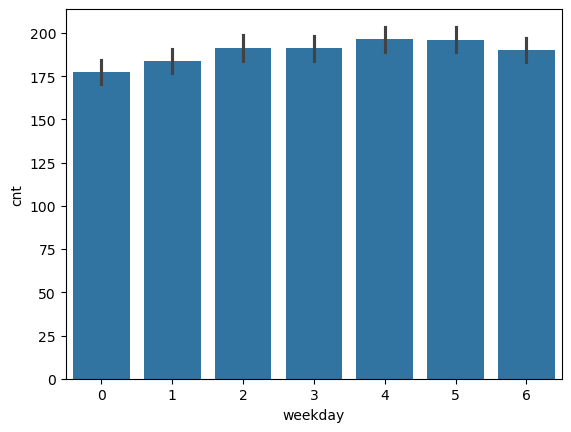

```python
sns.barplot(x="weekday", y="cnt", data=df, estimator=np.mean)
plt.show()
```

On observe une hausse progressive du nombre moyen de locations du jour 0 vers le jour 4. Le pic de demande est atteint autour des jours 4 et 5. Cela suggère une utilisation plus intensive en semaine probablement liée aux déplacements domicile–travail.

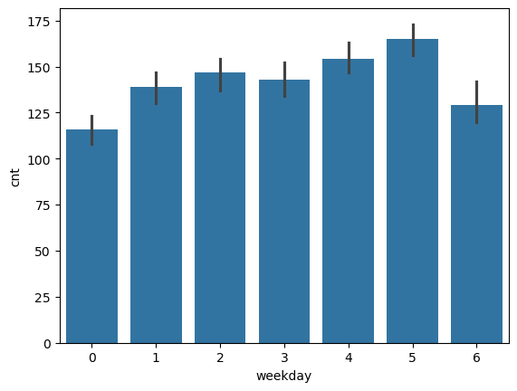

```python
sns.barplot(x="weekday", y="cnt", data=df, estimator=np.median)
plt.show()
```

Le jour 0 présente la demande médiane la plus faible. La médiane augmente progressivement jusqu’au jour 5 qui affiche le niveau le plus élevé. Le jour 6 montre une baisse nette par rapport au pic. Nous concluons qu'il y a une utilisation plus régulière et plus intense en semaine et un usage plus occasionnel le week-end.

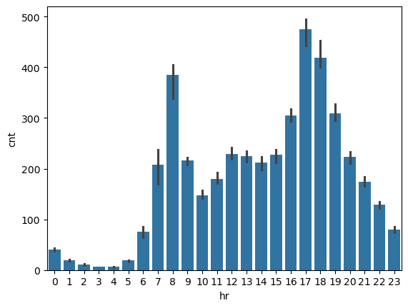

```python
sns.barplot(x="hr", y="cnt", data=df, estimator=np.median)
plt.show()
```

Nous observons une forte hausse entre 6h et 9h. Le pic est atteint à 8h. Ce fait met en évidence les trajets domicile et boulot / études.

Nous observons un pic maximal entre 17h et 19h avec un maximum autour de 17h. Ces niveaux sont nettement supérieurs au pic du matin. Cela met en évidence les retours du travail et les usages de loisirs.

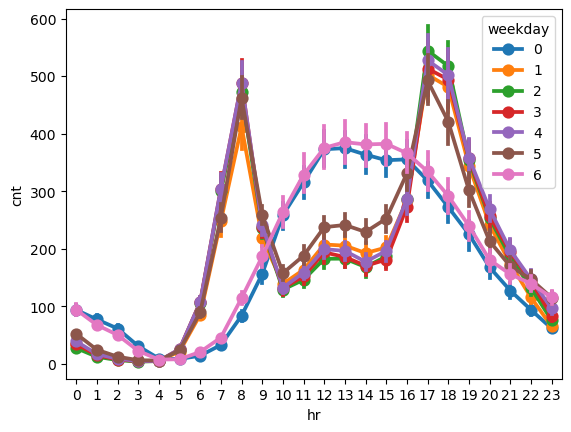

```python
sns.pointplot(data=df, x='hr', y='cnt', hue='weekday')
plt.show()
```

Le graphique met en évidence une interaction marquée entre l’heure de la journée et le jour de la semaine. Les jours ouvrés (jour 1 à jour 5) présentent une structure bimodale correspondant aux déplacements domicile–travail. Tandis que le week-end (jour 0 et jour 6) se caractérise par une demande plus diffuse et concentrée en milieu de journée correspondant ainsi aux déplacements pour loisir.

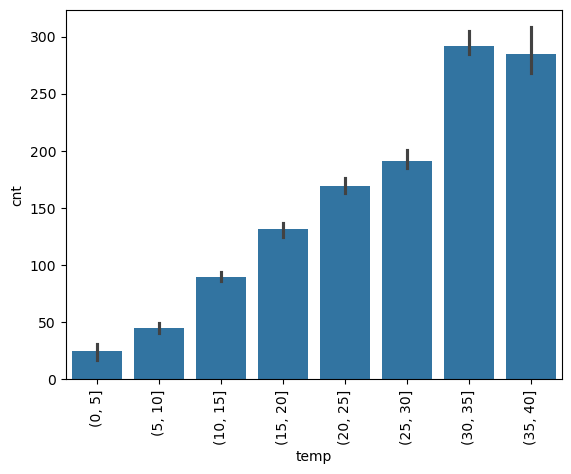

```python
temp_range = range(0, round(df["temp"].max()), 5)
temp_binned = pd.cut(df["temp"], bins=temp_range)
temp_plot = sns.barplot(x=temp_binned, y=df["cnt"], estimator=np.median)
plt.xticks(rotation=90)
plt.show()
```

On observe une augmentation de la demande médiane lorsque la température augmente. Les températures basses (0–5°C) sont associées à une demande très faible (usage moins confortable de vélos). La demande devient significative à partir de 10–15°C.

Le niveau maximal de la demande est atteint lorsque la température est autour de 30–35°C. On observe une légère baisse de la demande dans la classe 35–40°C. Cette baisse est probablement due à la chaleur extrême qui entraine un usage moins confortable des vélos.

**6) Montrez des graphiques supplémentaires pertinents vous permettant de mieux comprendre les facteurs d'impact sur le nombre de vélos loués. Pour chacun de ces graphiques vous proposerez une analyse.**

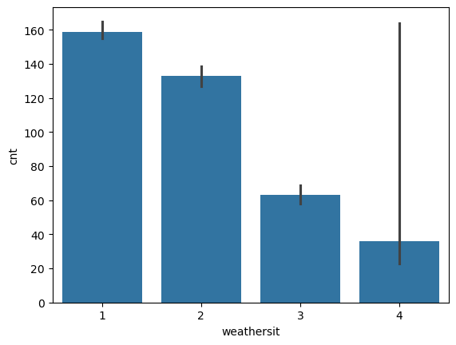

```python
sns.barplot(x="weathersit", y="cnt", data=df, estimator=np.median)
plt.show()
```

La demande diminue fortement lorsque les conditions météo se dégradent. La médiane passe d’environ 160 (temps dégagé) à 130 (brouillard). Puis, chute à environ 60 (pluie/neige légère), et à 35 en cas de fortes intempéries.

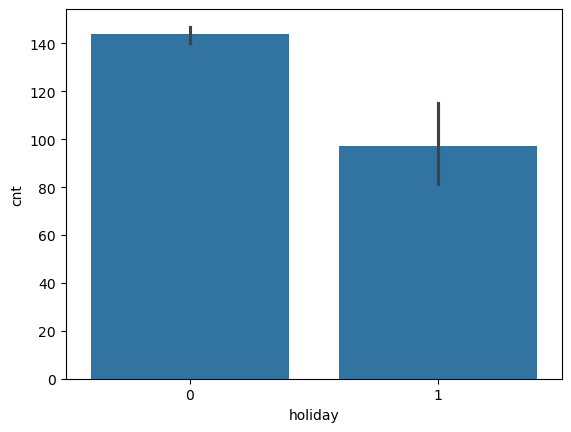

```python
sns.barplot(x="holiday", y="cnt", data=df, estimator=np.median)
plt.show()
```

Nous notons une baisse nette de la demande les jours fériés. La médiane passe d’environ 140 locations les jours non fériés à moins de 100 locations les jours fériés.

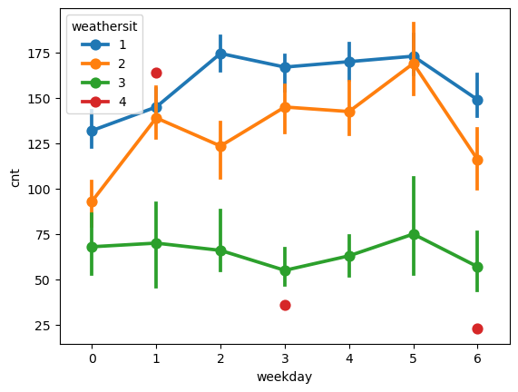

```python
sns.pointplot(data=df, x="weekday", y="cnt", hue="weathersit", estimator=np.median)
plt.show()
```

Nous constatons que les usagers adaptent leur comportement d’abord à la météo, ensuite au type de jour. Un jour ouvré avec pluie peut générer moins de demande qu’un week-end ensoleillé.

**7) Proposez une visualisation pertinente à partir d'une approche non-supervisée**

```python
# Préparation des données sans la vaiable cible(cnt)

features = ["season_labels", "mnth", "hr", "holiday", "weekday", "weathersit", "temp", "atemp", "hum", "windspeed"]

df_ns = df[features]
```

```python
# Encodage de la variable season_labels

df_ns = pd.get_dummies(df_ns, columns=["season_labels"], drop_first=True)
```

```python
# Imputation par la médiane des valeurs manquantes de la variable hum

from sklearn.impute import SimpleImputer
imputer = SimpleImputer(strategy="median")
df_imputed = imputer.fit_transform(df_ns)
```

```python
df_ns.dtypes
```

```
mnth                       category
hr                         category
holiday                    category
weekday                    category
weathersit                 category
temp                        float64
atemp                       float64
hum                         float64
windspeed                   float64
season_labels_Hiver            bool
season_labels_Printemps        bool
season_labels_Été              bool
dtype: object
```

```python
# Sélectionner uniquement les colonnes numériques

df_numeric = df_ns.select_dtypes(include=[np.number])

# Standardisation

from sklearn.preprocessing import StandardScaler
scaler = StandardScaler()
df_scaled = scaler.fit_transform(df_imputed)
```

```python
# Réduction de dimension (ACP)

from sklearn.decomposition import PCA
pca = PCA()
df_pca = pca.fit_transform(df_scaled)
```

```python
# Clustering (K-means)

from sklearn.cluster import KMeans

kmeans = KMeans(n_clusters=4, random_state=42)
clusters = kmeans.fit_predict(df_pca)
```

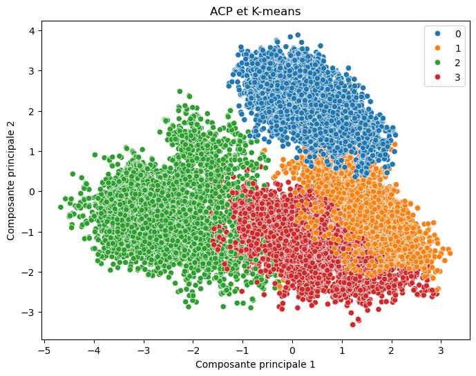

```python
plt.figure(figsize=(8,6))
sns.scatterplot(x=df_pca[:, 0], y=df_pca[:, 1], hue=clusters, palette="tab10")
plt.xlabel("Composante principale 1")
plt.ylabel("Composante principale 2")
plt.title("ACP et K-means")
plt.show()
```

La composante principale 1 (axe horizontal) sépare clairement à gauche (les conditions peu favorables à l’usage du vélo) et à droite (les conditions favorables). Cette composante est très probablement corrélée à la température (temp, atemp), la météo (weathersit) et indirectement à la saison.

La composante principale 2 (axe vertical) capte des différences temporelles / d’usage. Elle Oppose en haut (les périodes d’activité plus intense) et en bas (les périodes creuses) Cette composante est probablement liée à l’heure de la journée (hr) et le type de jour (weekday, holiday).

Le cluster bleu (en haut à droite) présente des conditions favorables. On constate une activité élevée. Il fait probablement référence aux heures de pointe, la météo clémente et les jours ouvrés.

Le cluster orange (en bas à droite) présente des conditions météo plutôt favorables. On constate une activité plus modérée. Il fait probablement référence aux soirées, aux périodes hors pics et les usages plus diffus.

Le cluster vert (à gauche) présente des conditions défavorables. On observe une faible activité. Il fait probablement référence aux températures basses, à la pluie et à la nuit / matin très tôt.

Le cluster rouge (au centre bas) présente des conditions intermédiaires. On observe une activité moyenne. Il fait probablement référence à la transition entre pics et creux.

## Feature Engineering

**8) Ajoutez à ce dataset une "feature" qui vous semble pertinente. Comment pouvez-vous évaluer l'apport potentiel de cette feature ? Montrez les graphiques ou tableaux pertinents pour appuyer votre réponse.**

```python
# Création de la feature 'heure de pointe'

df["is_peak_hour"] = df["hr"].isin([7, 8, 9, 17, 18, 19]).astype(int)
```

```python
# Tableau comparatif médiane et moyenne

df.groupby("is_peak_hour")["cnt"].agg(["mean", "median", "count"])
```

| is_peak_hour | mean | median | count |
| --- | --- | --- | --- |
| 0 | 141.765140 | 104.0 | 13012 |
| 1 | 331.584841 | 302.0 | 4367 |

Les heures de pointe ont un effet très fort car on constate que la moyenne du nombre de locations des vélos a plus que doublée en heure de pointe (332 vs 142). Aussi, la médiane est presque 3 fois plus élevée (302 vs 104). Cette feature a donc un impact majeur et non marginal.

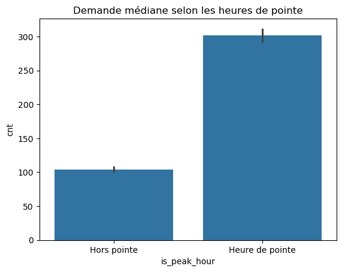

```python
sns.barplot(x="is_peak_hour", y="cnt", data=df, estimator=np.median)
plt.xticks([0,1], ["Hors pointe", "Heure de pointe"])
plt.title("Demande médiane selon les heures de pointe")
plt.show()
```

## Algorithmes et Validation (entraînement de l'algorithme prédictif)

Dans cette partie, vous allez entraîner un modèle prédictif pour prédire le nombre total de locations de vélos. **Utilisez la librairie sklearn** et lisez attentivement la documentation des fonctions que vous serez amenés à choisir. De manière générale, **commencez simple** et vous pourrez améliorer votre modèle dans la partie suivante, ou donner vos pistes de réflexion à la fin de ce TP.

**9) Séparez au sein du dataset vos jeux d'entraînement et de test. A quoi cette étape sert-elle ?**

La séparation du dataset en jeu d’entraînement et de test permet d'entraîner le modèle sur une partie des données et d'évaluer ses performances sur des données jamais vues pendant l’apprentissage. Cette étape est essentielle pour mesurer la capacité de généralisation du modèle et éviter le sur-apprentissage.

```python
df.dtypes
```

```
instant                   int64
dteday           datetime64[ns]
season                    int64
mnth                   category
hr                     category
holiday                category
weekday                category
weathersit             category
temp                    float64
atemp                   float64
hum                     float64
windspeed               float64
casual                    int64
registered                int64
cnt                       int64
season_labels          category
is_peak_hour              int32
dtype: object
```

```python
# Variables à exclure

X = df.drop(columns=["cnt", "casual", "registered", "instant", "dteday"])
y = df["cnt"]


# Encodage des variables catégorielles

cat_cols = X.select_dtypes(include=["category"]).columns

X = pd.get_dummies(X, columns=cat_cols, drop_first=True)


# Gestion des valeurs manquantes. Imputation par la médiane

from sklearn.impute import SimpleImputer

imputer = SimpleImputer(strategy="median")
X = imputer.fit_transform(X)



# Standardisation

from sklearn.preprocessing import StandardScaler

scaler = StandardScaler()
X = scaler.fit_transform(X)


# Découpage en 80 % entraînement et 20 % test

from sklearn.model_selection import train_test_split

X_train, X_test, y_train, y_test = train_test_split(X, y, test_size=0.2, random_state=42)
```

**10) Choisissez un modèle et indiquez les raisons de ce choix. Si des pré-traitements spécifiques sont nécessaires à la bonne exécution et performance de l'algorithme, vous les effectuerez ici en indiquant pourquoi ils sont nécessaires. Vous pourrez ensuite procéder à l'entraînement de votre modèle à l'aide de la fonction *fit* présente sur l'ensemble des estimateurs sklearn**

**Régression linéaire**

```python
# Entraînement de la régression linéaire

from sklearn.linear_model import LinearRegression

model = LinearRegression()
model.fit(X_train, y_train)
```

```
LinearRegression()
```

```python
# Prédiction sur le jeu de test

y_pred = model.predict(X_test)
```

**11) Ce premier modèle est-il performant ? Comment mesurez-vous sa performance et pourquoi ?**

```python
# Evaluation des performances en calculant la MAE et le RMSE

from sklearn.metrics import mean_absolute_error, mean_squared_error

mae = mean_absolute_error(y_test, y_pred)
rmse = mean_squared_error(y_test, y_pred, squared=False)

print("MAE :", mae)
print("RMSE :", rmse)
```

```
MAE : 78.10120514091055
RMSE : 108.86765360040556
```

La MAE est d’environ 78. Ce qui signifie que le modèle se trompe en moyenne de 78 locations de vélo par heure.

Le RMSE plus élevé (à peu près 109) indique que les erreurs sont plus importantes lors des périodes de forte activité.

Les métriques d’évaluation montrent des limites dans la prédiction des pics de location de vélo. Ce qui justifie l’exploration de modèles plus complexes dans la suite du travail.

## Améliorer le modèle

**12) Quelles données supplémentaires permettraient d’avoir une prédiction plus précise ? De quelles données aurait-on besoin pour assurer la maintenance complète des bornes de location ?**

Par exemple, les données sur le l'état des vélos à savoir le kilométrage, l'historique des réparations et le type de panne récurrente. Cela permettrait d'anticiper les pannes futures.

**13) Mettez en place les techniques de régularisation adaptées à l’algorithme choisi**

**Régression Ridge**

```python
from sklearn.linear_model import Ridge
from sklearn.metrics import mean_absolute_error, mean_squared_error

ridge = Ridge(alpha=1.0)
ridge.fit(X_train, y_train)

y_pred_ridge = ridge.predict(X_test)

mae_ridge = mean_absolute_error(y_test, y_pred_ridge)
rmse_ridge = mean_squared_error(y_test, y_pred_ridge, squared=False)

print("MAE :", mae_ridge)
print("RMSE :", rmse_ridge)
```

```
MAE : 78.07406075460447
RMSE : 108.85290151798019
```

**Régression Lasso**

```python
from sklearn.linear_model import Lasso

lasso = Lasso(alpha=0.1)
lasso.fit(X_train, y_train)

y_pred_lasso = lasso.predict(X_test)

mae_lasso = mean_absolute_error(y_test, y_pred_lasso)
rmse_lasso = mean_squared_error(y_test, y_pred_lasso, squared=False)

print("MAE :", mae_lasso)
print("RMSE :", rmse_lasso)
```

```
MAE : 78.02407936741218
RMSE : 108.86677039879092
```

**Elastic Net**

```python
from sklearn.linear_model import ElasticNet

elastic = ElasticNet(alpha=0.1, l1_ratio=0.5)
elastic.fit(X_train, y_train)

y_pred_elastic = elastic.predict(X_test)

mae_elastic = mean_absolute_error(y_test, y_pred_elastic)
rmse_elastic = mean_squared_error(y_test, y_pred_elastic, squared=False)

print("MAE :", mae_elastic)
print("RMSE :", rmse_elastic)
```

```
MAE : 78.4600587228712
RMSE : 109.42728535917388
```

```python
# Comparaison des modèles

pd.DataFrame({
    "Modèle": ["Linéaire", "Ridge", "Lasso", "ElasticNet"],
    "MAE": [mae, mae_ridge, mae_lasso, mae_elastic],
    "RMSE": [rmse, rmse_ridge, rmse_lasso, rmse_elastic]
})
```

|  | Modèle | MAE | RMSE |
| --- | --- | --- | --- |
| 0 | Linéaire | 78.101205 | 108.867654 |
| 1 | Ridge | 78.074061 | 108.852902 |
| 2 | Lasso | 78.024079 | 108.866770 |
| 3 | ElasticNet | 78.460059 | 109.427285 |

Les techniques de régularisation testées (Ridge, Lasso et Elastic Net) conduisent à des performances très proches de celles de la régression linéaire. Cependant, la régression Ridge présente le meilleur compromis en termes de stabilité et de performance bien que les gains restent marginaux.

**14) Mettez en place le choix des meilleurs hyperparamètres**

Ridge étant notre meilleur modèle linéaire, c'est celui qu'on va optimiser.

```python
# Recherche des meilleurs hyperparamètres (alpha)

from sklearn.linear_model import RidgeCV

ridge_cv = RidgeCV(alphas=[0.01, 0.1, 1, 10, 100])
ridge_cv.fit(X_train, y_train)

ridge_cv.alpha_
```

```
10.0
```

```python
# Entrement du modèle Ridge optimal

from sklearn.linear_model import Ridge

ridge_best = Ridge(alpha=ridge_cv.alpha_)
ridge_best.fit(X_train, y_train)
```

```
Ridge(alpha=10.0)
```

```python
# Prédiction sur le jeu de test

y_pred_ridge = ridge_best.predict(X_test)
```

```python
# Evaluation des performances

from sklearn.metrics import mean_absolute_error, mean_squared_error

mae_ridge = mean_absolute_error(y_test, y_pred_ridge)
rmse_ridge = mean_squared_error(y_test, y_pred_ridge, squared=False)

print("MAE Ridge (alpha optimal) :", mae_ridge)
print("RMSE Ridge (alpha optimal) :", rmse_ridge)
```

```
MAE Ridge (alpha optimal) : 78.06870607583481
RMSE Ridge (alpha optimal) : 108.85203008407012
```

```python
# Comparaison avec le modèle linéaire de base

pd.DataFrame({
    "Modèle": ["Linéaire", "Ridge optimisé"],
    "MAE": [mae, mae_ridge],
    "RMSE": [rmse, rmse_ridge]
})
```

|  | Modèle | MAE | RMSE |
| --- | --- | --- | --- |
| 0 | Linéaire | 78.101205 | 108.867654 |
| 1 | Ridge optimisé | 78.068706 | 108.852030 |

L’optimisation de l’hyperparamètre de régularisation de la régression Ridge conduit à une légère amélioration des performances par rapport au modèle linéaire de base. Ces résultats confirment l’intérêt de la régularisation pour stabiliser le modèle.

**15) Quelle(s) autre(s) approche(s) aurait pu être pertinente(s) ? Vous pourrez indiquer ici les pistes d'améliorations que vous envsageriez si vous étiez amené à poursuivre ce projet**

Les résultats obtenus avec les modèles linéaires (même régularisés) montrent des performances correctes mais très limitées. Comme piste d'améliorations, nous pourrions envisager l'utilisation des modèles non-linéaires tels les arbres de décision, les forêts aléatoires, GradientBoosting et XGBoost.